# CZ4073 : Assignment 2

Sharma Shantanu

U1622895F

### Targeted Marketing for Car Insurance

Suppose you the Data Scientist in a small Car Insurance company, and you want to judge if the Customers will accept or reject a new Insurance product that the company is going to launch. Your company did a pilot with 9000 customers and obtained the corresponding dataset. The classification goal is to learn from this pilot, and predict if a targeted customer will respond *Yes* to the offer. Your company also wants to identify the top three variables that may affect the response of the customers, and they also want to know how to increase the chances for the customers to respond *Yes* to the offered Insurance product.

### Analysis of Marketing Data

Import the CSV data file `assign2_MarketData.csv` for analysis, and quickly check the structure of the data.

```r
#install.packages("DMwR", repos = "https://cran.asia/")
#install.packages("tree", repos = "https://cran.asia/")
#install.packages("rpart", repos = "https://cran.asia/")
#install.packages("rpart.plot", repos = "https://cran.asia/")
#install.packages("randomForest", repos = "https://cran.asia/")
#install.packages("Boruta", repos = "https://cran.asia/")

library(DMwR)
library(tree)
library(rpart)
library(rpart.plot)
library(randomForest)
library(Boruta)
marketData <- read.csv("assign2_MarketData.csv", header = TRUE)
str(marketData)
```

```
## 'data.frame':    9000 obs. of  24 variables:
##  $ Customer                     : Factor w/ 9000 levels "AA10041","AA11235",..: 2035 721 1645 8505 6230 1997 8610 4163 338 5607 ...
##  $ State                        : Factor w/ 5 levels "Arizona","California",..: 4 2 2 2 4 3 1 2 2 2 ...
##  $ Customer.Lifetime.Value      : num  24179 5462 4890 7433 2237 ...
##  $ Coverage                     : Factor w/ 3 levels "Basic","Extended",..: 2 1 1 1 1 1 1 2 1 1 ...
##  $ Education                    : Factor w/ 5 levels "Bachelor","College",..: 2 4 1 2 2 3 4 4 1 1 ...
##  $ Effective.To.Date            : Factor w/ 59 levels "1/1/11","1/10/11",..: 18 29 57 7 54 31 30 31 23 33 ...
##  $ EmploymentStatus             : Factor w/ 5 levels "Disabled","Employed",..: 2 2 2 2 5 1 5 2 5 5 ...
##  $ Gender                       : Factor w/ 2 levels "F","M": 2 1 1 1 1 1 2 2 1 1 ...
##  $ Income                       : int  43704 39626 46819 58839 0 25703 0 44379 0 0 ...
##  $ Location.Code                : Factor w/ 3 levels "Rural","Suburban",..: 2 2 3 1 2 2 2 2 2 2 ...
##  $ Marital.Status               : Factor w/ 3 levels "Divorced","Married",..: 2 2 1 3 2 2 3 2 3 3 ...
##  $ Monthly.Premium.Auto         : int  201 69 62 65 61 62 107 83 101 116 ...
##  $ Months.Since.Last.Claim      : int  29 23 15 4 19 4 22 10 10 12 ...
##  $ Months.Since.Policy.Inception: int  67 0 0 65 44 64 96 12 48 76 ...
##  $ Number.of.Open.Complaints    : int  0 0 0 3 0 0 0 1 0 1 ...
##  $ Number.of.Policies           : int  2 3 5 2 1 1 4 8 2 2 ...
##  $ Policy.Type                  : Factor w/ 3 levels "Corporate Auto",..: 2 2 2 2 2 2 2 3 2 2 ...
##  $ Policy                       : Factor w/ 9 levels "Corporate L1",..: 6 6 5 6 5 6 5 9 6 6 ...
##  $ Renew.Offer.Type             : Factor w/ 4 levels "Offer1","Offer2",..: 1 2 1 1 3 1 4 2 1 1 ...
##  $ Sales.Channel                : Factor w/ 4 levels "Agent","Branch",..: 2 1 1 3 1 3 4 3 1 1 ...
##  $ Total.Claim.Amount           : num  1064 486 158 19 293 ...
##  $ Vehicle.Class                : Factor w/ 6 levels "Four-Door Car",..: 3 1 1 6 1 1 5 1 5 5 ...
##  $ Vehicle.Size                 : Factor w/ 3 levels "Large","Medsize",..: 2 1 1 2 3 3 2 2 2 3 ...
##  $ Response                     : Factor w/ 2 levels "No","Yes": 1 1 1 1 1 1 1 1 1 1 ...
```

```r
summary(marketData)
```

```
##     Customer           State      Customer.Lifetime.Value     Coverage
##  AA10041:   1   Arizona   :1679   Min.   : 1898           Basic   :5495
##  AA11235:   1   California:3100   1st Qu.: 3997           Extended:2691
##  AA16582:   1   Nevada    : 871   Median : 5780           Premium : 814
##  AA30683:   1   Oregon    :2567   Mean   : 8002
##  AA34092:   1   Washington: 783   3rd Qu.: 8955
##  AA35519:   1                     Max.   :83325
##  (Other):8994
##                 Education    Effective.To.Date      EmploymentStatus Gender
##  Bachelor            :2708   1/10/11: 191      Disabled     : 402    F:4587
##  College             :2641   1/27/11: 190      Employed     :5617    M:4413
##  Doctor              : 334   2/14/11: 185      Medical Leave: 422
##  High School or Below:2580   1/26/11: 178      Retired      : 279
##  Master              : 737   1/31/11: 176      Unemployed   :2280
##                              1/3/11 : 175
##                              (Other):7905
##      Income       Location.Code   Marital.Status Monthly.Premium.Auto
##  Min.   :    0   Rural   :1755   Divorced:1349   Min.   : 61.00
##  1st Qu.:    0   Suburban:5690   Married :5221   1st Qu.: 68.00
##  Median :33922   Urban   :1555   Single  :2430   Median : 83.00
##  Mean   :37698                                   Mean   : 93.21
##  3rd Qu.:62399                                   3rd Qu.:109.00
##  Max.   :99981                                   Max.   :298.00
##
##  Months.Since.Last.Claim Months.Since.Policy.Inception
##  Min.   : 0.0            Min.   : 0.00
##  1st Qu.: 6.0            1st Qu.:24.00
##  Median :14.0            Median :48.00
##  Mean   :15.1            Mean   :48.05
##  3rd Qu.:23.0            3rd Qu.:71.00
##  Max.   :35.0            Max.   :99.00
##
##  Number.of.Open.Complaints Number.of.Policies         Policy.Type
##  Min.   :0.0000            Min.   :1.000      Corporate Auto:1940
##  1st Qu.:0.0000            1st Qu.:1.000      Personal Auto :6685
##  Median :0.0000            Median :2.000      Special Auto  : 375
##  Mean   :0.3837            Mean   :2.966
##  3rd Qu.:0.0000            3rd Qu.:4.000
##  Max.   :5.0000            Max.   :9.000
##
##           Policy     Renew.Offer.Type     Sales.Channel  Total.Claim.Amount
##  Personal L3 :3373   Offer1:3690      Agent      :3427   Min.   :   0.099
##  Personal L2 :2086   Offer2:2888      Branch     :2529   1st Qu.: 271.059
##  Personal L1 :1226   Offer3:1411      Call Center:1739   Median : 382.565
##  Corporate L3: 999   Offer4:1011      Web        :1305   Mean   : 433.659
##  Corporate L2: 588                                       3rd Qu.: 547.200
##  Corporate L1: 353                                       Max.   :2893.240
##  (Other)     : 375
##        Vehicle.Class   Vehicle.Size  Response
##  Four-Door Car:4557   Large  : 931   No :7713
##  Luxury Car   : 160   Medsize:6330   Yes:1287
##  Luxury SUV   : 182   Small  :1739
##  Sports Car   : 473
##  SUV          :1774
##  Two-Door Car :1854
##
```

The goal is to predict the response variable `Response` for each person – that is, whether a person would accept the new *Insurance Product* being offered by your company. Before doing that, tag the variables under **Demographic Profile** or **Insurance Profile** of the customers, as per our understanding.

The variables can be listed as follows:

[output not shown]

`Customer`, which appears to be like the primary key is irrelevant for our output variable. `Effective.to.Date` is also widely spread and does not hold any meaningful information. Most of the variables that have been classified as *Demographic* represent information relevant to the people and their surroundings. Culture and society can be a deteminant of most of these variables thereby being defined as Demographic. For example, the `State`, `Location.Code`, `Gender`, `Marital Status`, etc. are all personal information that do no add any definitive value to understanding the insurance aspect of any individual. Simliarly, variables that have been defined as *Insurance Policy* are the ones which involve factors that appear to be relevant while taking decisions pertaining to someone’s insurance. These involve `Income`, `Number.of.Policies`, etc.

#### Problem 1

Build an optimal tree-based classification model for `Response` vs just the **Insurance Profile** of a customer. Check the relevant accuracy parameters of your model, and use it to predict `Response` in the `assign2_MarketPred.csv`.

- Identify the *top three* important variables in this case.
- Why are they important? Justify in terms of the Pilot data.
- How would you influence `Response` using these variables?

#### Answer 1

**Exploratory Data Analaysis**

Sieve Insurance Profile variables for analysis

```r
# Demographic profile = {State, Education, EmploymentStatus, Gender, Location.Code, Marital.Status, Vehicle.Class, Vehicle.Size}

# Insurance Profile = {Customer.Lifetime.Value, Coverage, Income, Monthly.Premium.Auto, Months.Since.Last.Claim, Months.Since.Policy.Inception, Number.of.Open.Complaints, Number.of.Policies, Policy.Type, Policy, Renew.Offer.Type, Sales.Channel, Total.Claim.Account}

insuranceMarketData <- subset(marketData, select = -c(Customer, State, Education, Effective.To.Date, EmploymentStatus, Gender, Location.Code, Marital.Status, Vehicle.Class, Vehicle.Size, Number.of.Open.Complaints))
dim(insuranceMarketData)
```

```
## [1] 9000   13
```

```r
names(insuranceMarketData)
```

```
##  [1] "Customer.Lifetime.Value"       "Coverage"
##  [3] "Income"                        "Monthly.Premium.Auto"
##  [5] "Months.Since.Last.Claim"       "Months.Since.Policy.Inception"
##  [7] "Number.of.Policies"            "Policy.Type"
##  [9] "Policy"                        "Renew.Offer.Type"
## [11] "Sales.Channel"                 "Total.Claim.Amount"
## [13] "Response"
```

```r
summary(insuranceMarketData)
```

```
##  Customer.Lifetime.Value     Coverage        Income      Monthly.Premium.Auto
##  Min.   : 1898           Basic   :5495   Min.   :    0   Min.   : 61.00
##  1st Qu.: 3997           Extended:2691   1st Qu.:    0   1st Qu.: 68.00
##  Median : 5780           Premium : 814   Median :33922   Median : 83.00
##  Mean   : 8002                           Mean   :37698   Mean   : 93.21
##  3rd Qu.: 8955                           3rd Qu.:62399   3rd Qu.:109.00
##  Max.   :83325                           Max.   :99981   Max.   :298.00
##
##  Months.Since.Last.Claim Months.Since.Policy.Inception Number.of.Policies
##  Min.   : 0.0            Min.   : 0.00                 Min.   :1.000
##  1st Qu.: 6.0            1st Qu.:24.00                 1st Qu.:1.000
##  Median :14.0            Median :48.00                 Median :2.000
##  Mean   :15.1            Mean   :48.05                 Mean   :2.966
##  3rd Qu.:23.0            3rd Qu.:71.00                 3rd Qu.:4.000
##  Max.   :35.0            Max.   :99.00                 Max.   :9.000
##
##          Policy.Type            Policy     Renew.Offer.Type     Sales.Channel
##  Corporate Auto:1940   Personal L3 :3373   Offer1:3690      Agent      :3427
##  Personal Auto :6685   Personal L2 :2086   Offer2:2888      Branch     :2529
##  Special Auto  : 375   Personal L1 :1226   Offer3:1411      Call Center:1739
##                        Corporate L3: 999   Offer4:1011      Web        :1305
##                        Corporate L2: 588
##                        Corporate L1: 353
##                        (Other)     : 375
##  Total.Claim.Amount Response
##  Min.   :   0.099   No :7713
##  1st Qu.: 271.059   Yes:1287
##  Median : 382.565
##  Mean   : 433.659
##  3rd Qu.: 547.200
##  Max.   :2893.240
##
```

```r
#str(insuranceMarketData)
```

**Data Pre-Processing**

The data provided has no NULL value. Changing *integer* value to *categorical* for ease of analysis wherever possible

```r
insuranceMarketData$Number.of.Policies <- as.factor(insuranceMarketData$Number.of.Policies)
```

Understanding relation of varaible with response variable i.e. the outpur variable:

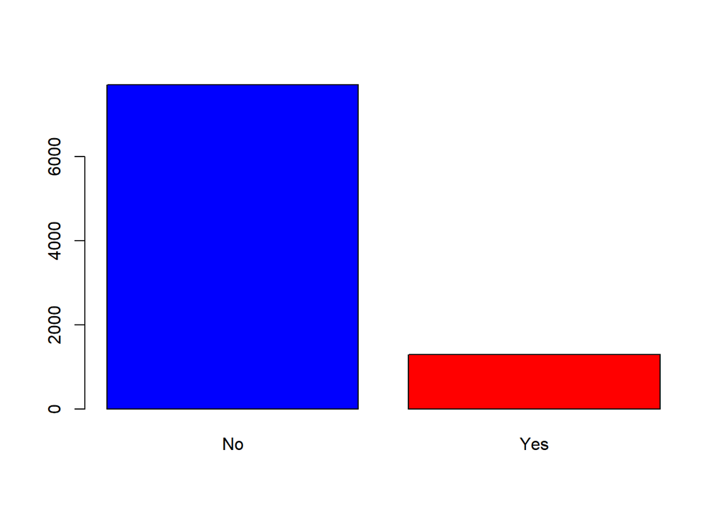

```r
colors <- c("blue","red")
plot(insuranceMarketData['Response'], col=colors)
```

The data is highly unbalanced as can be seen from the above graph. Hence we have to do Synthetic Data Generation to balance out minority data. SMOTE (Synthetic Minority Oversampling TEchnique) algorithm creates artificial data based on feature space (rather than data space) similarities from minority samples i.e. forming clusters and oversample the minority in order to minimize the imbalance in the classes available in the training data.

```r
# Data Mining with R (DMwR) library to be used for SMOTE
library(DMwR)
balancedMarketData <- SMOTE(Response ~ ., data = insuranceMarketData, perc.over = 250, perc.under = 150)
summary(balancedMarketData)
```

```
##  Customer.Lifetime.Value     Coverage        Income      Monthly.Premium.Auto
##  Min.   : 1918           Basic   :4424   Min.   :    0   Min.   : 61.00
##  1st Qu.: 4334           Extended:2517   1st Qu.:16255   1st Qu.: 71.00
##  Median : 5908           Premium : 781   Median :33290   Median : 84.00
##  Mean   : 7736                           Mean   :37761   Mean   : 93.12
##  3rd Qu.: 8938                           3rd Qu.:60074   3rd Qu.:108.00
##  Max.   :83325                           Max.   :99960   Max.   :297.00
##
##  Months.Since.Last.Claim Months.Since.Policy.Inception Number.of.Policies
##  Min.   : 0.00           Min.   : 0.00                 1      :2736
##  1st Qu.: 7.00           1st Qu.:26.00                 2      :1844
##  Median :14.04           Median :49.00                 3      : 938
##  Mean   :15.06           Mean   :48.06                 9      : 527
##  3rd Qu.:22.48           3rd Qu.:69.00                 5      : 371
##  Max.   :35.00           Max.   :99.00                 7      : 365
##                                                        (Other): 941
##          Policy.Type            Policy     Renew.Offer.Type     Sales.Channel
##  Corporate Auto:2174   Personal L3 :2541   Offer1:3293      Agent      :3079
##  Personal Auto :5138   Personal L2 :1639   Offer2:3104      Branch     :2103
##  Special Auto  : 410   Corporate L3:1053   Offer3: 816      Call Center:1412
##                        Personal L1 : 968   Offer4: 509      Web        :1128
##                        Corporate L2: 715
##                        Corporate L1: 394
##                        (Other)     : 412
##  Total.Claim.Amount  Response
##  Min.   :   0.4233   No :3861
##  1st Qu.: 296.0471   Yes:3861
##  Median : 398.4000
##  Mean   : 429.3861
##  3rd Qu.: 532.8318
##  Max.   :2452.8943
##
```

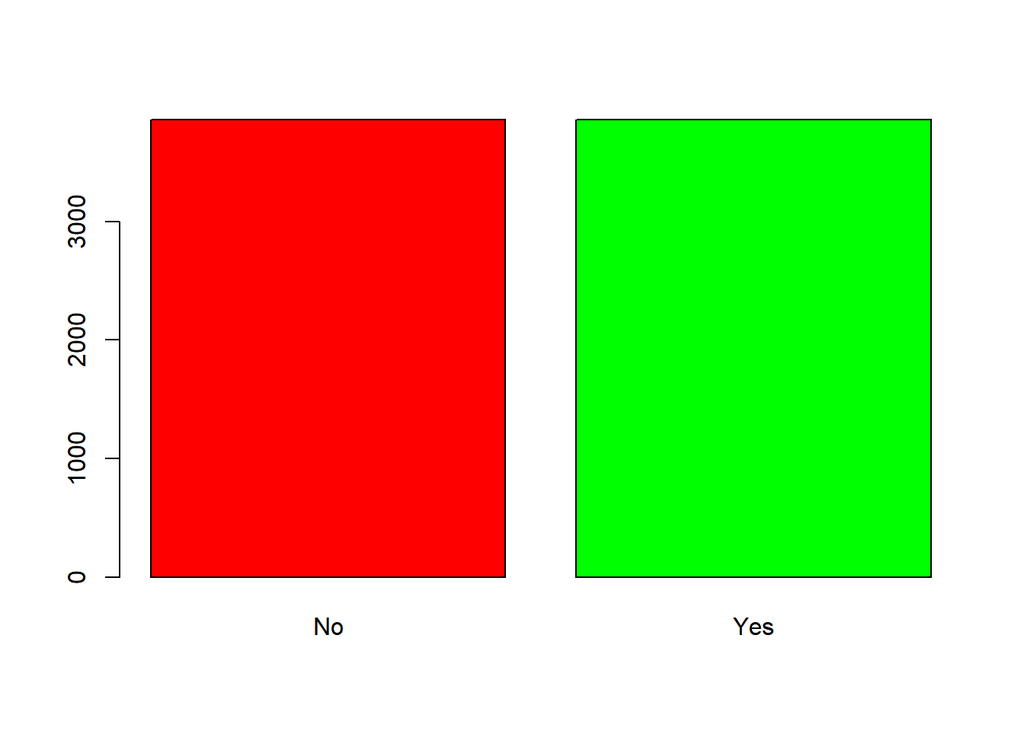

```r
#summary(insuranceMarketData)
colors <- c("red","green")
plot(balancedMarketData['Response'], col=colors)
```

Oversampling via Oversampling/Interpolation makes data balanced with respect to output. 50-50 Yes and No response for output variable.

**Data Analysis**

We divide the data first into Discrete variable and Continuous variable to draw inference:

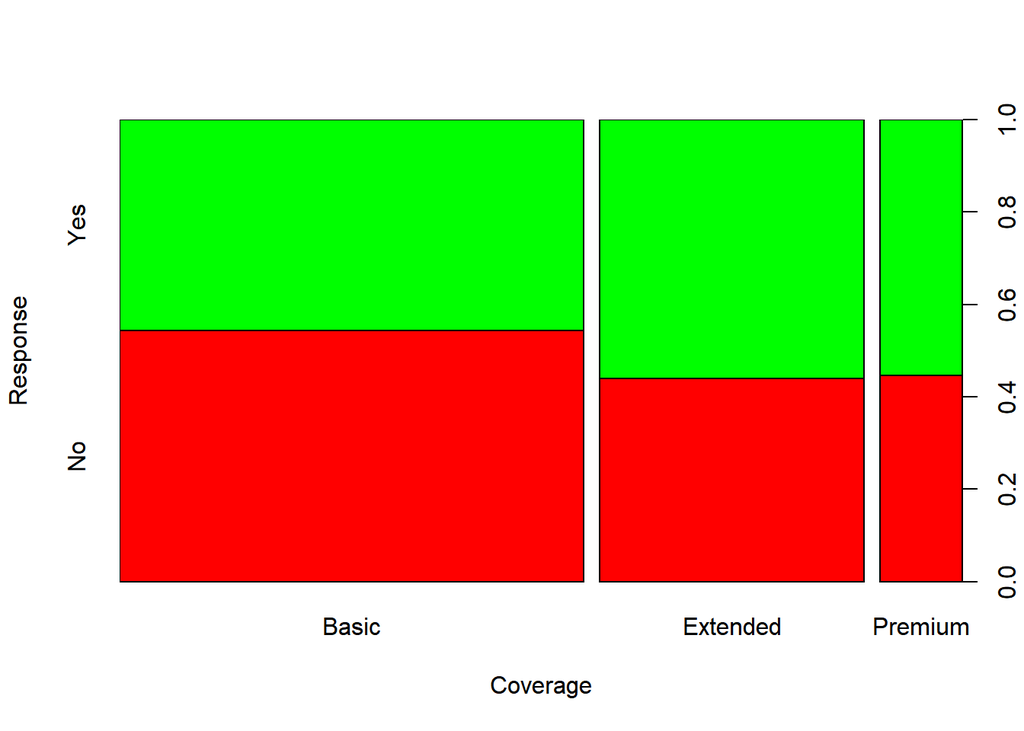

```r
# Performing analysis for categorical data
cols <- c("red","green")

plot(balancedMarketData$Coverage, balancedMarketData$Response,
     xlab="Coverage", ylab="Response", col=cols)
```

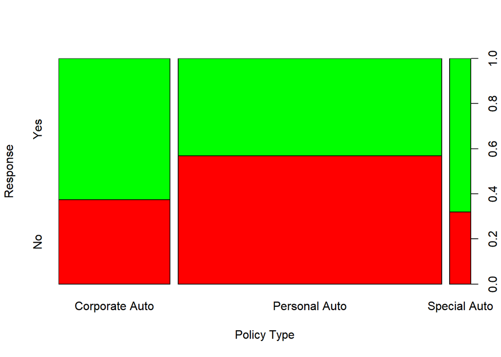

```r
plot(balancedMarketData$Policy.Type, balancedMarketData$Response,
     xlab="Policy Type", ylab="Response", col=cols)
```

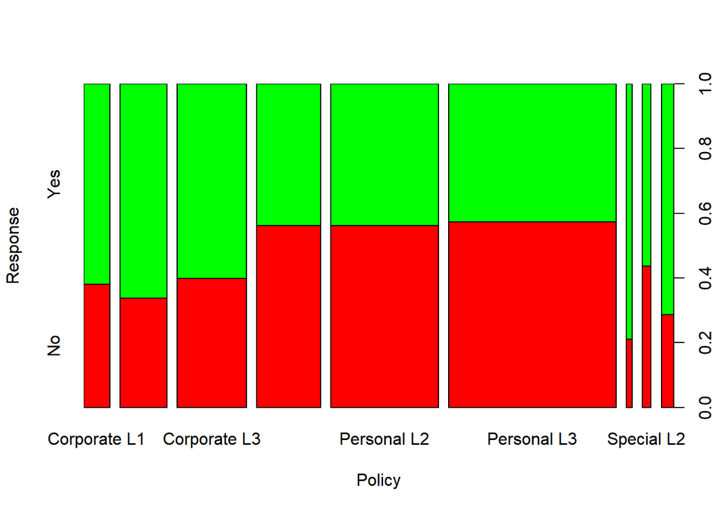

```r
plot(balancedMarketData$Policy, balancedMarketData$Response,
     xlab="Policy", ylab="Response", col=cols)
```

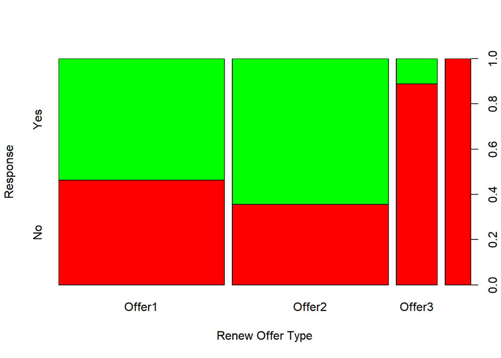

```r
plot(balancedMarketData$Renew.Offer.Type, balancedMarketData$Response,
     xlab="Renew Offer Type", ylab="Response", col=cols)
```

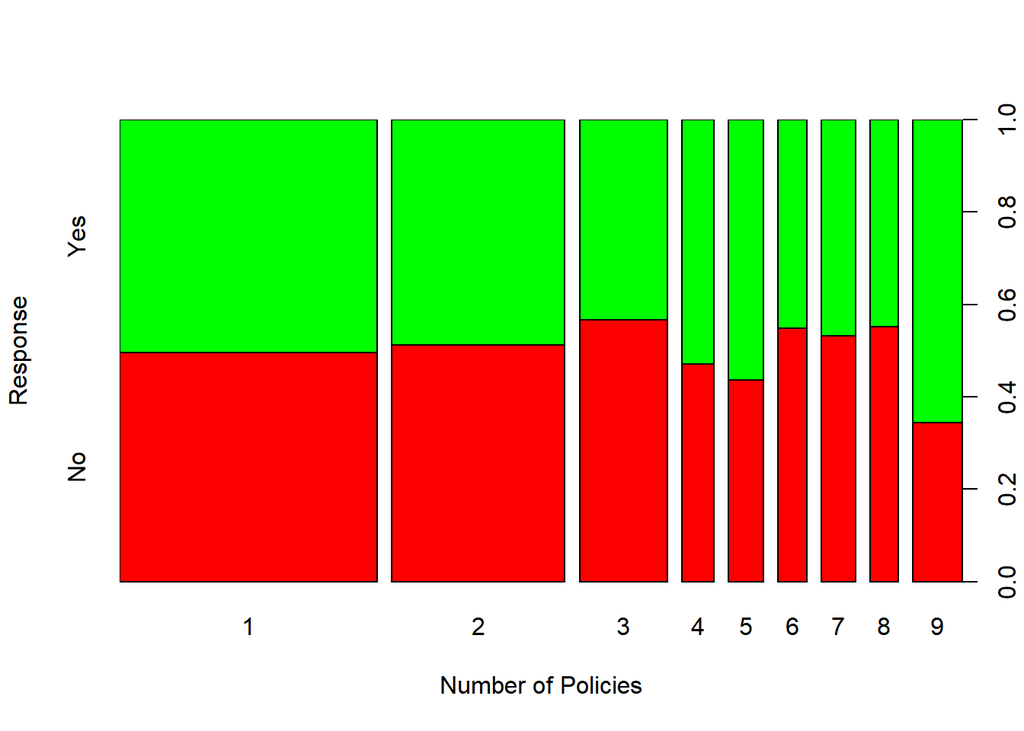

```r
plot(balancedMarketData$Number.of.Policies, balancedMarketData$Response,
     xlab="Number of Policies", ylab="Response", col=cols)
```

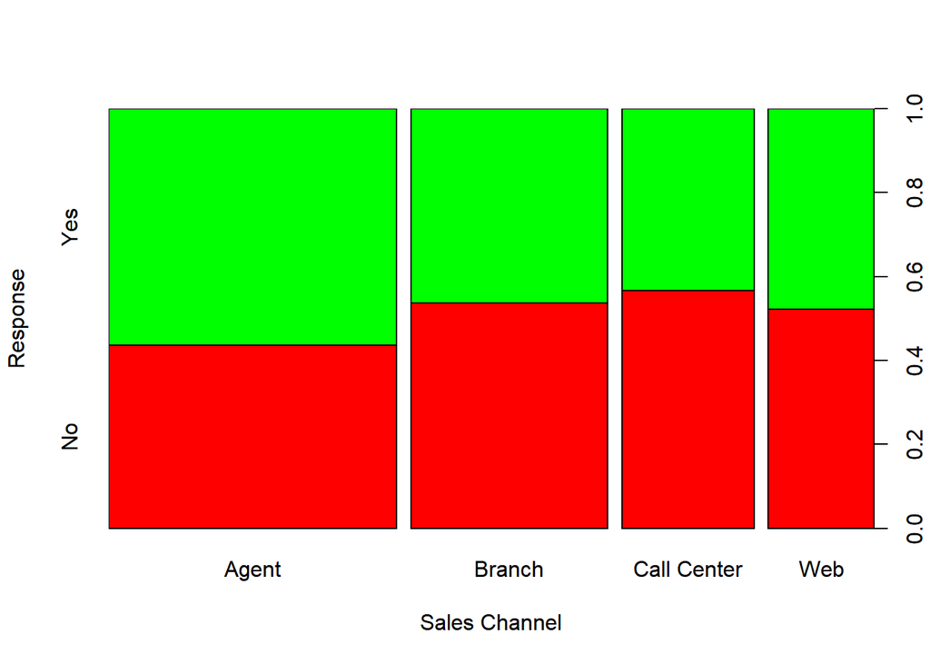

```r
plot(balancedMarketData$Sales.Channel, balancedMarketData$Response,
     xlab="Sales Channel", ylab="Response", col=cols)
```

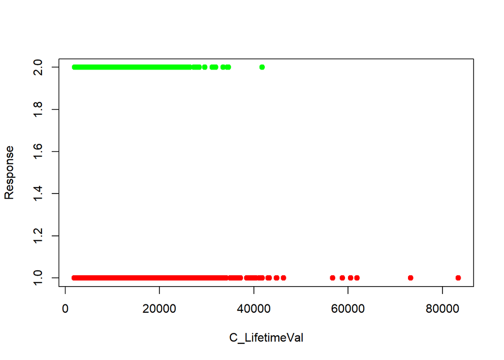

```r
# Performing analysis for continuous data

plot(balancedMarketData$Customer.Lifetime.Value, balancedMarketData$Response, xlab="C_LifetimeVal",
     ylab="Response", pch = 19, col = cols[(balancedMarketData$Response)])
```

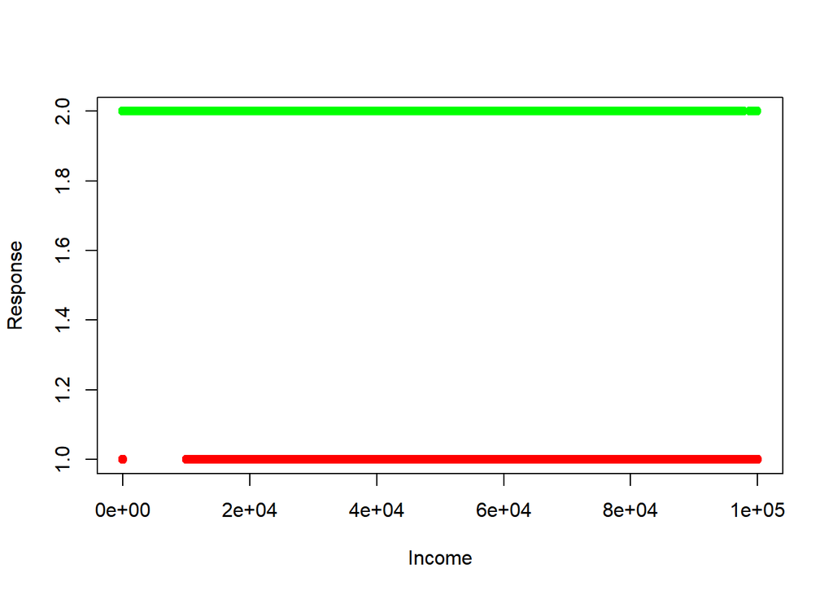

```r
plot(balancedMarketData$Income, balancedMarketData$Response, xlab="Income",
     ylab="Response", pch = 19, col = cols[(balancedMarketData$Response)])
```

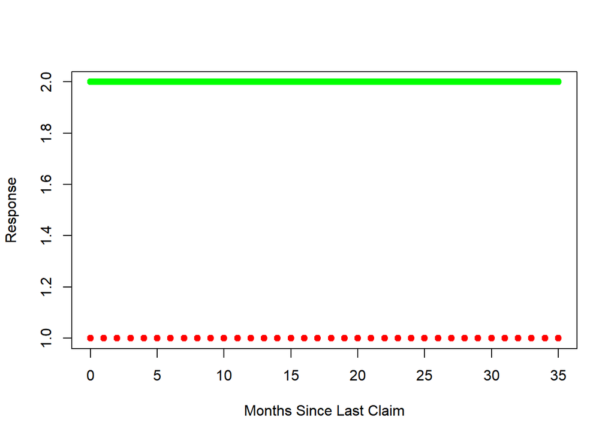

```r
plot(balancedMarketData$Months.Since.Last.Claim, balancedMarketData$Response, xlab="Months Since Last Claim",
     ylab="Response", pch = 19, col = cols[(balancedMarketData$Response)])
```

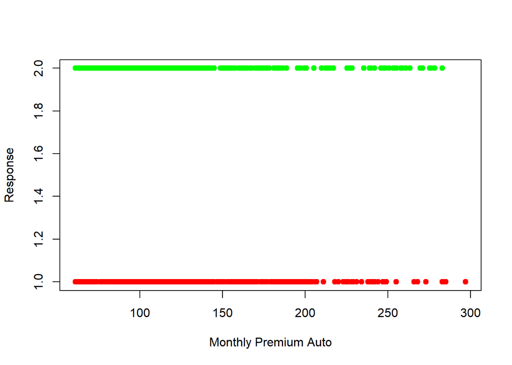

```r
plot(balancedMarketData$Monthly.Premium.Auto, balancedMarketData$Response, xlab="Monthly Premium Auto",
     ylab="Response", pch = 19, col = cols[(balancedMarketData$Response)])
```

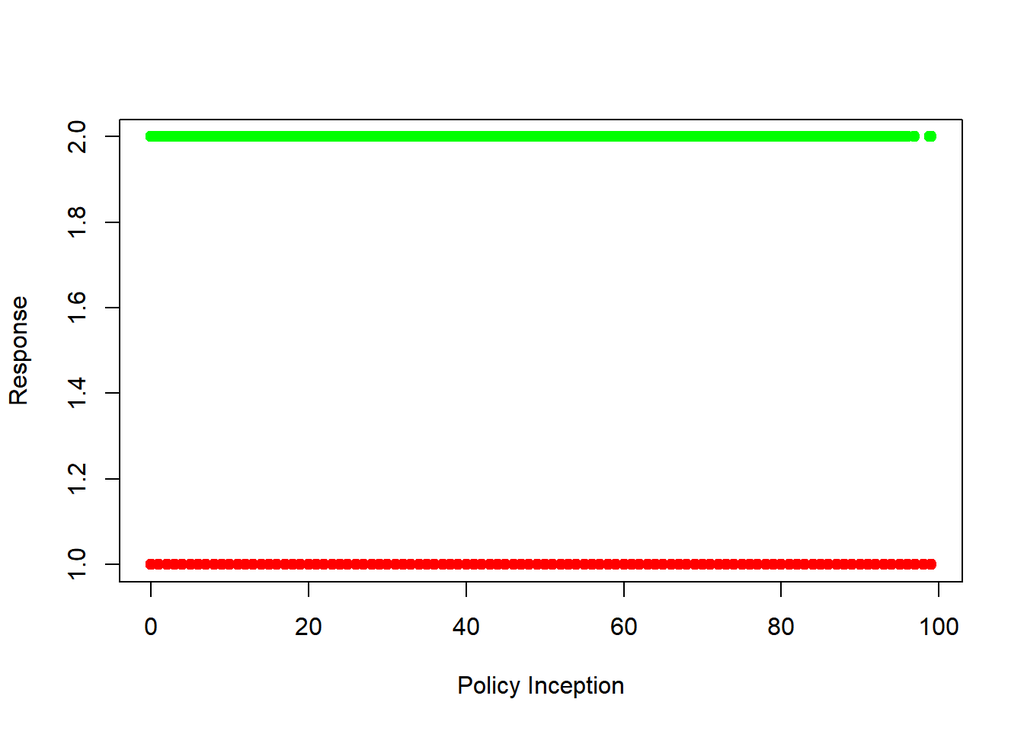

```r
plot(balancedMarketData$Months.Since.Policy.Inception, balancedMarketData$Response, xlab="Policy Inception",
     ylab="Response", pch = 19, col = cols[(balancedMarketData$Response)])
```

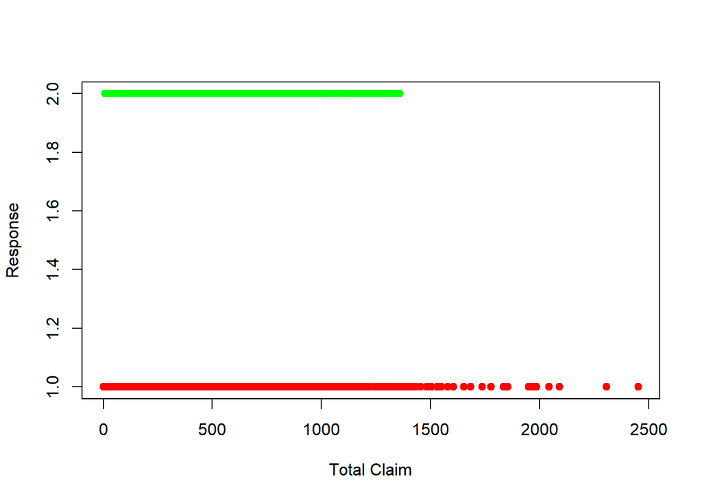

```r
plot(balancedMarketData$Total.Claim.Amount, balancedMarketData$Response, xlab="Total Claim",
     ylab="Response", pch = 19, col = cols[(balancedMarketData$Response)])
```

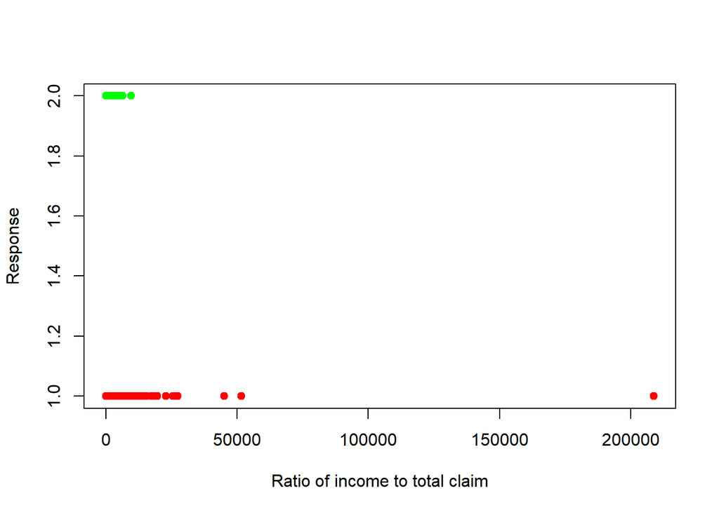

```r
# Income can be zero but insurance claim and income are not zero simultaneously
ratio_Income_TotalClaim= c(balancedMarketData$Income/ balancedMarketData$Total.Claim.Amount)
zero_indices = c (which(ratio_Income_TotalClaim==0) , which(ratio_Income_TotalClaim>400000) )

#NewMatrixData <- cbind(balancedMarketData,ratio_Income_TotalClaim)
# Removing values that have ration equal zero and outlier
indices_new=  !(c(1:length(ratio_Income_TotalClaim)) %in% zero_indices)
Response_withoutZeroRatio= balancedMarketData$Response[indices_new]
ratio_Income_TotalClaim_without0= ratio_Income_TotalClaim[indices_new]

plot(ratio_Income_TotalClaim_without0, Response_withoutZeroRatio, xlab="Ratio of income to total claim",
     ylab="Response", pch = 19, col = cols[Response_withoutZeroRatio])
```

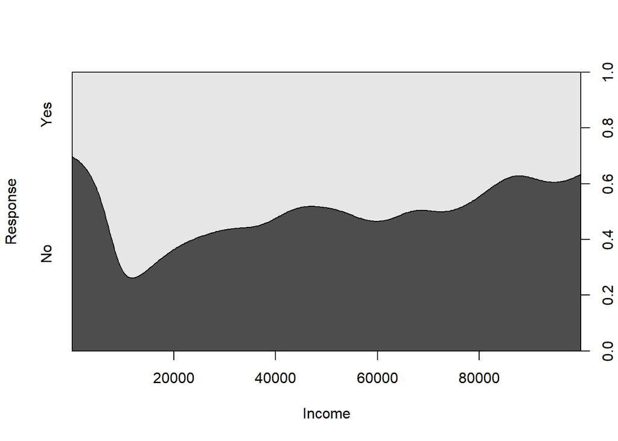

```r
# second (cdPlots)

cdplot(balancedMarketData$Income, balancedMarketData$Response, xlab="Income",
     ylab="Response")
```

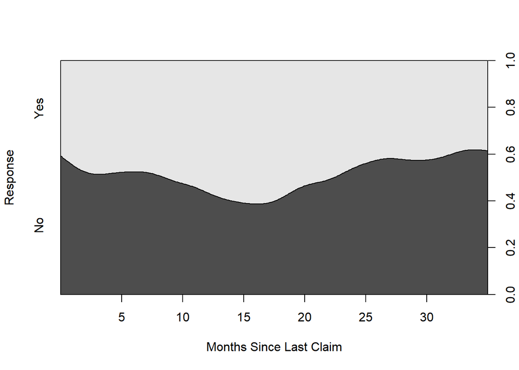

```r
cdplot(balancedMarketData$Months.Since.Last.Claim, balancedMarketData$Response, xlab="Months Since Last Claim",
     ylab="Response")
```

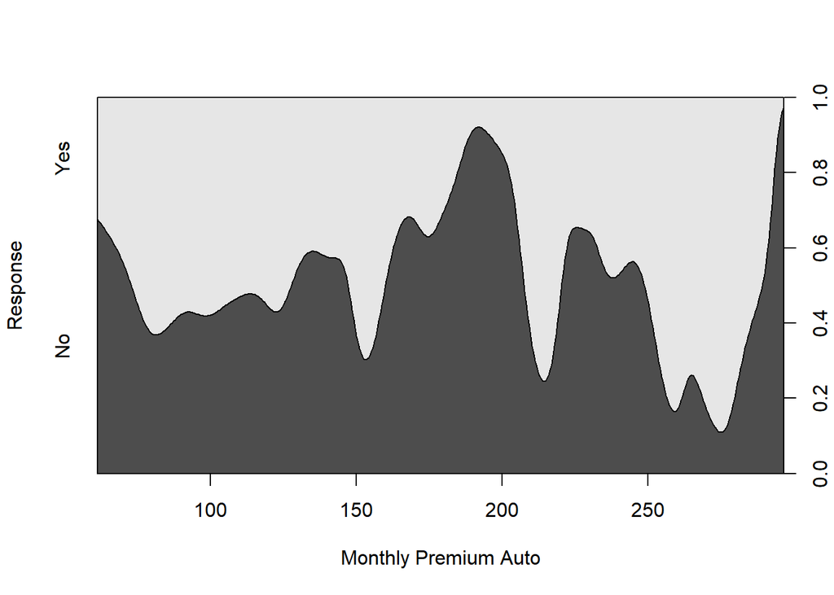

```r
cdplot(balancedMarketData$Monthly.Premium.Auto, balancedMarketData$Response, xlab="Monthly Premium Auto",
     ylab="Response")
```

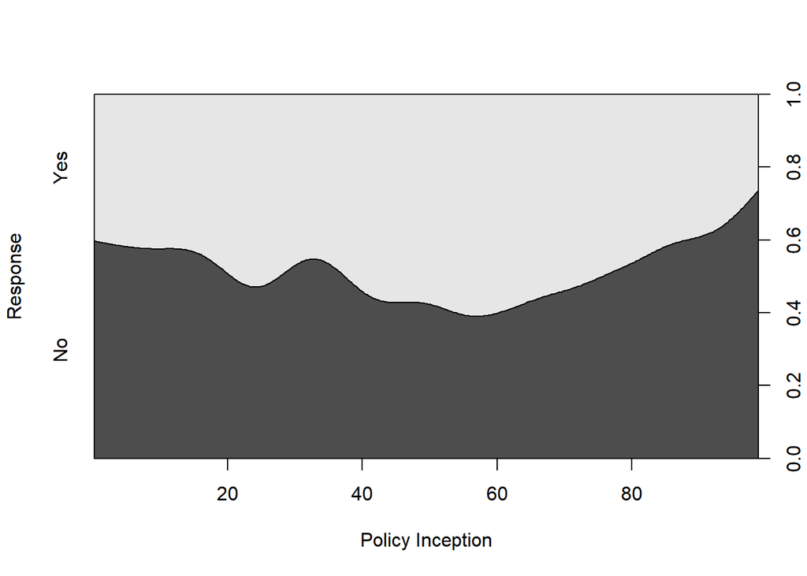

```r
cdplot(balancedMarketData$Months.Since.Policy.Inception, balancedMarketData$Response, xlab="Policy Inception",
     ylab="Response")
```

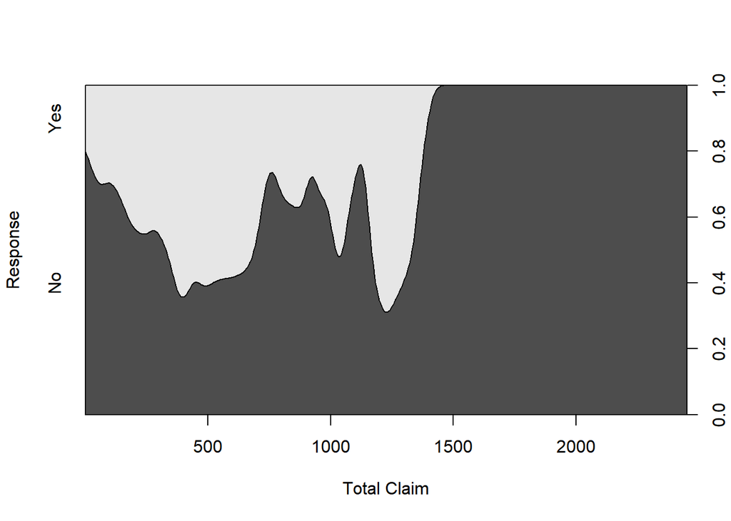

```r
cdplot(balancedMarketData$Total.Claim.Amount, balancedMarketData$Response, xlab="Total Claim",
     ylab="Response")
```

For `Customer Lifetime Value`, people with higher value seem to be more inclined towards responding No.

Consumers with `Customer Lifetime Value` have inclination towards response variable as No. Similarily, for `Income to Total Claim ratio`, the higher the ratio, the higher the response to be No. Meaning that if the claim is little as compared to the Income of a person, the consumer tends to refuse to take the new insurance being offered.

**Model Building**

Train Data:Test Data :: 70:30

```r
train <- sample(nrow(balancedMarketData), 0.7*nrow(balancedMarketData), replace = FALSE)
TrainData <- balancedMarketData[train,]
TestData <- balancedMarketData[-train,]
```

Decision Tree Modelling-

```r
library(rpart)
library(rpart.plot)
treeFitModel <- rpart(Response ~ ., data = TrainData, method = 'class', control = rpart.control(cp=0))
PredBase <- predict(treeFitModel, TrainData, type = 'class')
accuracyBase <- mean(PredBase == TestData$Response)
accuracyBase
```

```
## [1] 0.5089732
```

```r
printcp(treeFitModel)
```

```
##
## Classification tree:
## rpart(formula = Response ~ ., data = TrainData, method = "class",
##     control = rpart.control(cp = 0))
##
## Variables actually used in tree construction:
##  [1] Coverage                      Customer.Lifetime.Value
##  [3] Income                        Monthly.Premium.Auto
##  [5] Months.Since.Last.Claim       Months.Since.Policy.Inception
##  [7] Number.of.Policies            Policy
##  [9] Policy.Type                   Renew.Offer.Type
## [11] Sales.Channel                 Total.Claim.Amount
##
## Root node error: 2682/5405 = 0.49621
##
```

[output cut: 37 more lines]

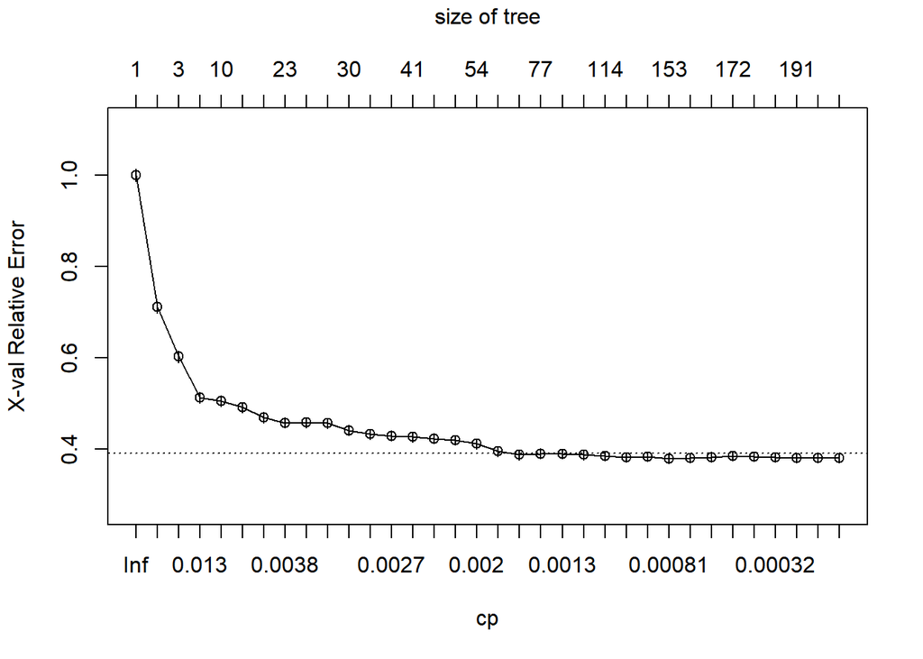

```r
plotcp(treeFitModel)
```

The above plot give insight to pruning to enable better optimality and performance of the model. We are going to perform pre-pruning and post-pruning of the decision tree. Minimum value of *xerror* helps in finding optimal value of CP.

*Pre-Pruning*

```r
PrePruneM <- rpart(Response ~ ., data = TrainData, method = 'class', control = rpart.control(cp=0, maxdepth = 12,minsplit = 100))
PredBasePrePruned <- predict(PrePruneM, TestData, type = 'class')
accuracyPrePruned <- mean(PredBasePrePruned == TestData$Response)
accuracyPrePruned
```

```
## [1] 0.7716875
```

*Post-Pruning*

Pruning after unfolding using CP obtained.

```r
PostPruneM <- prune(treeFitModel, cp = 0.00092)
PredBasePostPruned <- predict(PostPruneM, TestData, type = 'class')
accuracyPostPruned <- mean(PredBasePostPruned == TestData$Response)
accuracyPostPruned
```

```
## [1] 0.8178679
```

Post pruning resulted in greater performance.

*Random Forest Classification*

Random forest classification can also be used in order to attempt to enhance performance by using either GINI/ deviance/ Miscalssfication error as loss function. Random Forest Fit usually takes longer time to run due to various permutations being carried out

```r
library("randomForest")

rfFit <- randomForest(Response ~ .,
                      data = TrainData,
                      ntree = 1000,
                      mtry = 4,
                      importance = TRUE)

rfFit
```

```
##
## Call:
##  randomForest(formula = Response ~ ., data = TrainData, ntree = 1000,      mtry = 4, importance = TRUE)
##                Type of random forest: classification
##                      Number of trees: 1000
## No. of variables tried at each split: 4
##
##         OOB estimate of  error rate: 6.09%
## Confusion matrix:
##       No  Yes class.error
## No  2498  225  0.08262945
## Yes  104 2578  0.03877703
```

```r
predRF <- predict(rfFit, TestData, type="class")
mean(predRF == TestData$Response)
```

```
## [1] 0.9374191
```

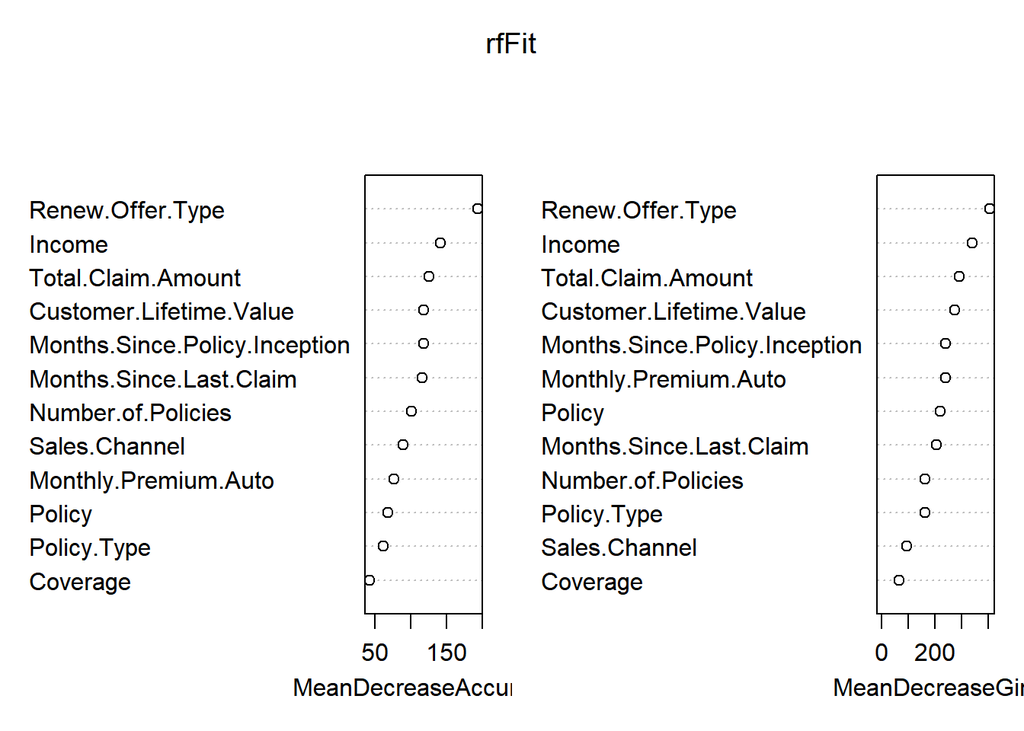

```r
varImpPlot(rfFit)
```

From the graph, the *three* most important variables in Insurance Policy are `Renew.Offer.Type`, `Income` and `Total.Claim.Account` as predicted in our analysis earlier. Removal of last few variables can help in improving the accuracy and getting an optimal random forest tree.

Explaination for importance of variable:

*Income* also acts plays an important role as was guessed while performing the initial data analysis. People with higher incomes do not find the offer attractive enough and either the offer has to be ailroed to suit their needs or target audience should be reevaluated.

*Renew offer type*: the offer given to consumer determines whether it will be chosen or not. Certain offer types are highly unlikely to be chosen as pointed it in earlier analysis

*Total claim account* probably plays such a huge role as in the initial graph as high claim amounts do not attract people as much.

Ration of Income and Total Claim Amount also forms a distinguishing important variable for analysis

Hence, as discussed in the above section, modifications should be made to the target audience and the methodology of offers in order to get more positive responses.

**Prediction using random forest classification**

```r
marketPred <- read.csv("assign2_MarketPred.csv", header = TRUE)
marketPredFiltered = subset(marketPred, select = -c(Customer, State, Education, Effective.To.Date, EmploymentStatus, Gender, Location.Code, Marital.Status, Vehicle.Class, Vehicle.Size, Number.of.Open.Complaints))
marketPredFiltered$Number.of.Policies <- as.factor(marketPredFiltered$Number.of.Policies)
marketPredFiltered$Monthly.Premium.Auto <- as.numeric(marketPredFiltered$Monthly.Premium.Auto)
marketPredFiltered$Income <- as.numeric(marketPredFiltered$Income)
marketPredFiltered$Months.Since.Last.Claim <- as.numeric(marketPredFiltered$Months.Since.Last.Claim)
marketPredFiltered$Months.Since.Policy.Inception <- as.numeric(marketPredFiltered$Months.Since.Policy.Inception)

levels(marketPredFiltered$Policy) <- levels(marketData$Policy)

str(marketPredFiltered)
```

```
## 'data.frame':    100 obs. of  12 variables:
##  $ Customer.Lifetime.Value      : num  4737 3934 14642 3589 5839 ...
##  $ Coverage                     : Factor w/ 3 levels "Basic","Extended",..: 1 1 2 2 1 1 2 1 1 2 ...
##  $ Income                       : num  0 25927 0 42836 81082 ...
##  $ Monthly.Premium.Auto         : num  68 103 133 89 73 64 131 73 186 129 ...
##  $ Months.Since.Last.Claim      : num  2 6 24 32 5 11 12 18 0 24 ...
##  $ Months.Since.Policy.Inception: num  26 20 46 99 85 64 76 45 30 50 ...
##  $ Number.of.Policies           : Factor w/ 9 levels "1","2","3","4",..: 3 1 2 1 4 1 1 5 2 2 ...
##  $ Policy.Type                  : Factor w/ 3 levels "Corporate Auto",..: 2 2 2 1 2 1 2 2 2 2 ...
##  $ Policy                       : Factor w/ 9 levels "Corporate L1",..: 6 6 6 3 6 3 5 5 6 6 ...
##  $ Renew.Offer.Type             : Factor w/ 4 levels "Offer1","Offer2",..: 1 2 1 3 2 4 2 1 2 1 ...
##  $ Sales.Channel                : Factor w/ 4 levels "Agent","Branch",..: 2 4 1 2 1 3 3 3 2 1 ...
##  $ Total.Claim.Amount           : num  326 675 1387 245 281 ...
```

```r
str(TrainData)
```

```
## 'data.frame':    5405 obs. of  13 variables:
##  $ Customer.Lifetime.Value      : num  10799 6239 5488 8609 25831 ...
##  $ Coverage                     : Factor w/ 3 levels "Basic","Extended",..: 2 2 1 1 1 2 1 1 1 2 ...
##  $ Income                       : num  23926 0 15994 79090 73760 ...
##  $ Monthly.Premium.Auto         : num  99.7 91 90 107 107 ...
##  $ Months.Since.Last.Claim      : num  10 25 22.1 2 16 ...
##  $ Months.Since.Policy.Inception: num  75.7 63 25.8 74 3 ...
##  $ Number.of.Policies           : Factor w/ 9 levels "1","2","3","4",..: 1 3 1 3 2 1 6 5 3 7 ...
##  $ Policy.Type                  : Factor w/ 3 levels "Corporate Auto",..: 2 1 2 2 2 2 2 1 2 2 ...
##  $ Policy                       : Factor w/ 9 levels "Corporate L1",..: 2 2 3 4 5 6 4 5 6 5 ...
##  $ Renew.Offer.Type             : Factor w/ 4 levels "Offer1","Offer2",..: 2 1 2 2 3 1 2 3 1 2 ...
##  $ Sales.Channel                : Factor w/ 4 levels "Agent","Branch",..: 1 1 2 2 4 1 4 1 1 2 ...
##  $ Total.Claim.Amount           : num  489 655 480 289 230 ...
##  $ Response                     : Factor w/ 2 levels "No","Yes": 2 1 2 2 1 2 1 2 2 2 ...
```

```r
rfP1Pred = predict(rfFit, marketPredFiltered, type="class")

rfP1PredFrame <- data.frame("Response"=rfP1Pred)
write.csv(rfP1PredFrame, "assign2_MarketPred_Insurance.csv", row.names = TRUE)
```

#### Problem 2

Build an optimal tree-based classification model for `Response` vs both **Demographic Profile** and **Insurance Profile** of a customer. Check the relevant accuracy parameters of your model, and use it to predict `Response` in the `assign2_MarketPred.csv`.

- Identify the *top three* important variables in this case.
- Why are they important? Justify in terms of the Pilot data.
- How would you influence `Response` using these variables?

#### Answer 2

**Exploratory Data Analysis**

The overall structure of this solution remains more or less similar to the previous one. There are a few other parameters that are taken into consideration (Demographic Policy).

*Data Pre-Processing*

```r
MarketData_2 <- subset(marketData, select = -c(Customer, Effective.To.Date, Number.of.Open.Complaints))
MarketData_2$Number.of.Policies <- as.factor(MarketData_2$Number.of.Policies)
```

Balancing Response Variable-

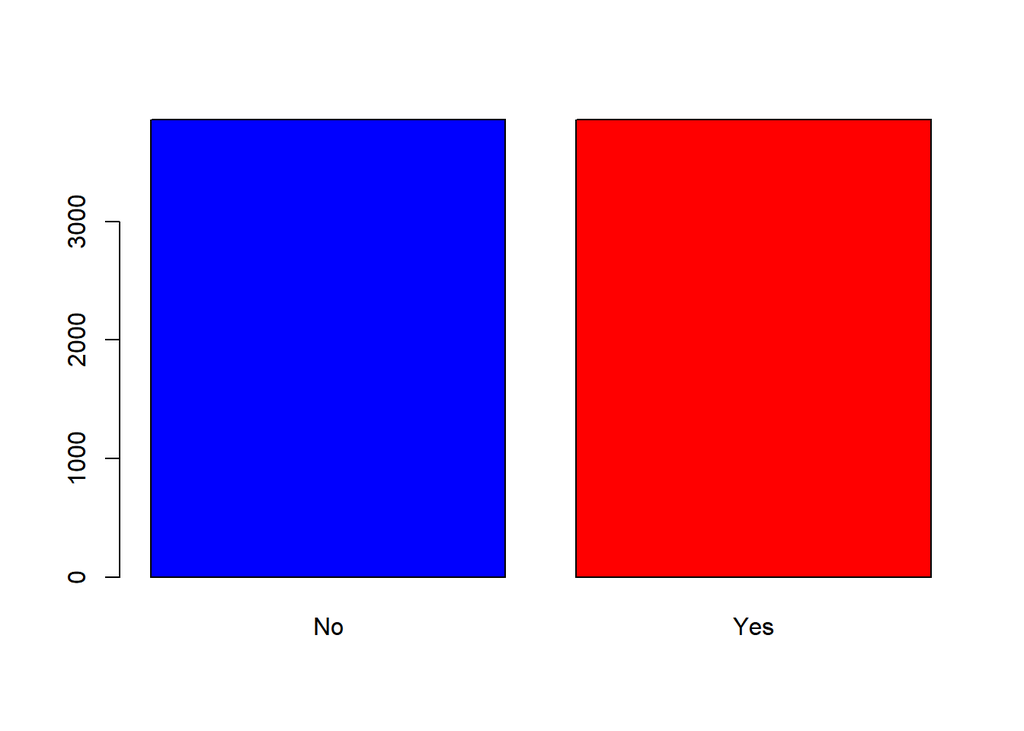

```r
cols <- c("blue","red")
#plot(MarketData_2['Response'], col=cols)
balOvrMarketData <- SMOTE(Response ~ ., data = MarketData_2, perc.over = 250, perc.under = 150)
plot(balOvrMarketData['Response'], col=cols)
```

*Data Analysis*

Plots for discrete variables

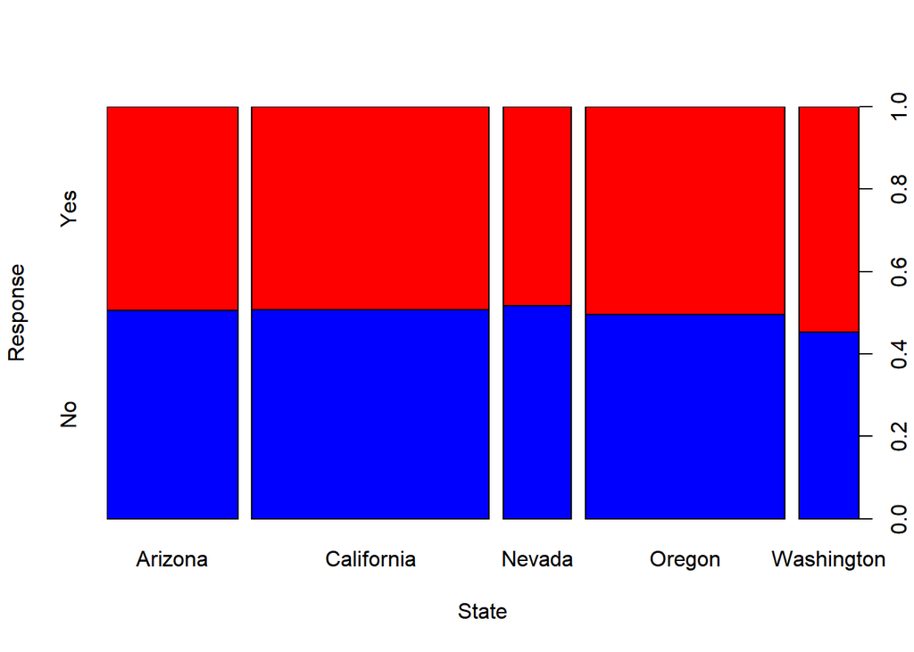

```r
plot(balOvrMarketData$State, balOvrMarketData$Response,
     xlab="State", ylab="Response", col=cols)
```

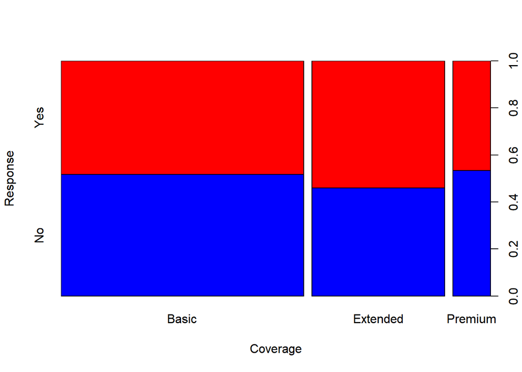

```r
plot(balOvrMarketData$Coverage, balOvrMarketData$Response,
     xlab="Coverage", ylab="Response", col=cols)
```

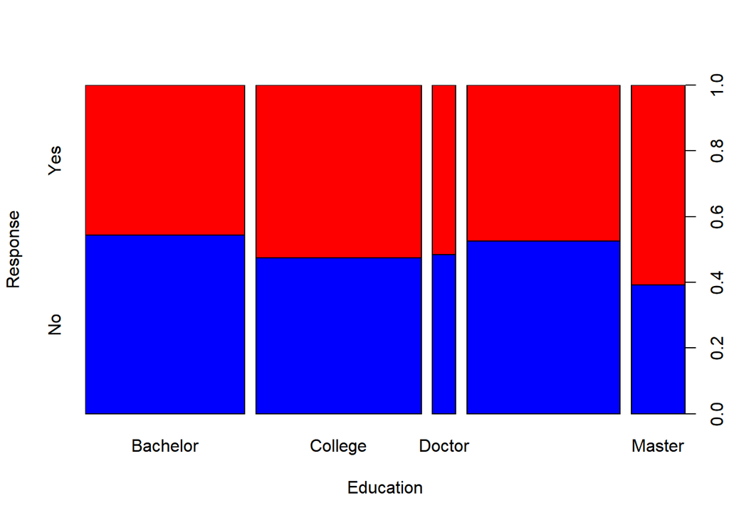

```r
plot(balOvrMarketData$Education, balOvrMarketData$Response,
     xlab="Education", ylab="Response", col=cols)
```

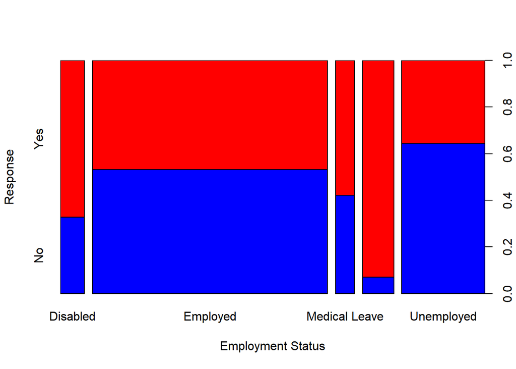

```r
plot(balOvrMarketData$EmploymentStatus, balOvrMarketData$Response,
     xlab="Employment Status", ylab="Response", col=cols)
```

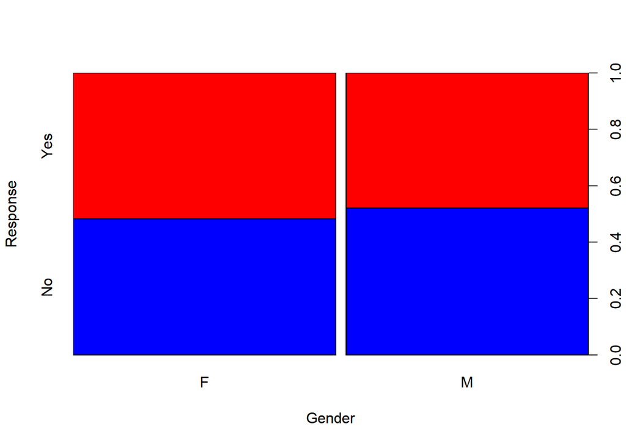

```r
plot(balOvrMarketData$Gender, balOvrMarketData$Response,
     xlab="Gender", ylab="Response", col=cols)
```

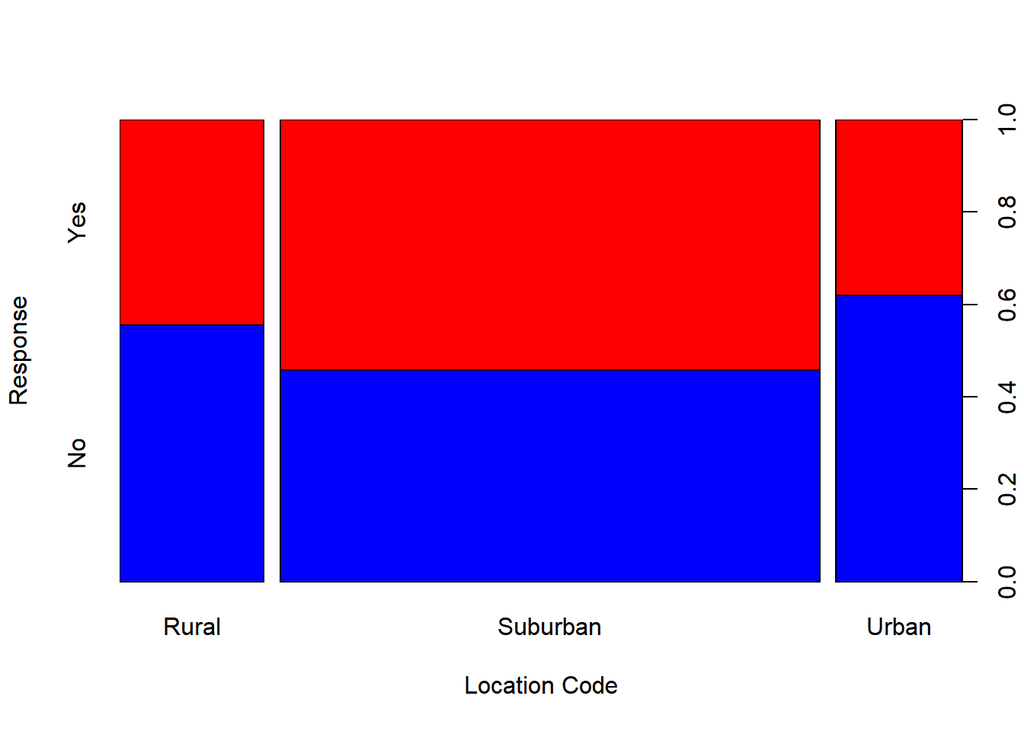

```r
plot(balOvrMarketData$Location.Code, balOvrMarketData$Response,
     xlab="Location Code", ylab="Response", col=cols)
```